# Practice makes perfect

Author

XXX

Published

April 27, 2026

## 1 Prepare Session

Load the required libraries, import, screen and correct the data.

```r
  library(pastecs)
  library(ggplot2)
  library(ggpubr); theme_set(theme_bw())
  library(GGally)
  library(performance)
  library(MuMIn)
  library(ggeffects)
  library(tidyverse)
  library(broom)
  library(car)

  library(knitr)                                     # To render tables

# Import data
  soup <- read.csv("~/Desktop/Practice_10/Data/raw/SpicySoup.csv", stringsAsFactors= T)
#if there is a coloumn in the table  that has non-numeric values do stringsasfactors = T so they convert into factors --> VERY ideal for modeling
# Factors are what R uses for categorical variables in models (like treatment groups).

# clean and unterstand data
# data$col <- ifelse(data$col == "Yes", 1, 0) --> if data column is no/yes and you need 1/0 for fiting models!!!
str(soup) # shows data typ and preview of the columns
```

```
'data.frame':   60 obs. of  5 variables:
 $ batch    : int  1 2 3 4 5 6 7 8 9 10 ...
 $ spice    : num  7.6 7.5 1.9 2 3.1 2.7 3.6 2.3 3.6 6.5 ...
 $ temp     : num  62.6 62.6 68.6 63 69.4 62.8 70.9 70.9 66.4 63 ...
 $ n_trials : int  38 29 43 38 27 30 37 44 41 24 ...
 $ successes: int  9 4 12 5 6 2 8 4 8 1 ...
```

```r
summary(soup) #numeric → mean, min, max, etc.+ factors → counts per category
```

```
     batch           spice            temp          n_trials
 Min.   : 1.00   Min.   :0.100   Min.   :62.10   Min.   :18.00
 1st Qu.:15.75   1st Qu.:2.200   1st Qu.:63.98   1st Qu.:24.00
 Median :30.50   Median :4.100   Median :67.40   Median :31.00
 Mean   :30.50   Mean   :4.060   Mean   :67.15   Mean   :31.25
 3rd Qu.:45.25   3rd Qu.:5.475   3rd Qu.:69.90   3rd Qu.:38.25
 Max.   :60.00   Max.   :7.900   Max.   :72.00   Max.   :45.00
   successes
 Min.   : 0.000
 1st Qu.: 3.000
 Median : 5.000
 Mean   : 6.233
 3rd Qu.: 8.250
 Max.   :27.000
```

```r
# Add an additional column to express the proportion of success in each batch of trials
  soup$prop<- soup$successes/soup$n_trials
```

## 2 Explore the data

It’s always a good idea to get to know your data, both by exploring them numerically and graphically. Since I asked you to write the units of the variables in the main text (because one of them contains a Greek letter), let’s give that a go:

### 2.1 Numerically

In Table 1 we see descriptive statistics for the variables of interest.

```
[1] 0.2457223
```

```
[1] 0.4866484
```

Table 1: Descriptive statistics for the variables of interest

|  | successes | temp | spice | n_trials | prop |
| --- | --- | --- | --- | --- | --- |
| nbr.val | 60.0 | 60.0 | 60.0 | 60.0 | 60.0 |
| nbr.null | 2.0 | 0.0 | 0.0 | 0.0 | 2.0 |
| nbr.na | 0.0 | 0.0 | 0.0 | 0.0 | 0.0 |
| min | 0.0 | 62.1 | 0.1 | 18.0 | 0.0 |
| max | 27.0 | 72.0 | 7.9 | 45.0 | 0.6 |
| range | 27.0 | 9.9 | 7.8 | 27.0 | 0.6 |
| sum | 374.0 | 4028.9 | 243.6 | 1875.0 | 11.6 |
| median | 5.0 | 67.4 | 4.1 | 31.0 | 0.2 |
| mean | 6.2 | 67.1 | 4.1 | 31.2 | 0.2 |
| SE.mean | 0.6 | 0.4 | 0.3 | 1.1 | 0.0 |
| CI.mean.0.95 | 1.2 | 0.8 | 0.6 | 2.2 | 0.0 |
| var | 20.9 | 9.5 | 4.9 | 71.2 | 0.0 |
| std.dev | 4.6 | 3.1 | 2.2 | 8.4 | 0.1 |
| coef.var | 0.7 | 0.0 | 0.5 | 0.3 | 0.6 |
| skewness | 1.7 | -0.1 | 0.1 | 0.0 | 1.0 |
| skew.2SE | 2.7 | -0.1 | 0.1 | 0.0 | 1.7 |
| kurtosis | 5.1 | -1.3 | -1.1 | -1.4 | 1.7 |
| kurt.2SE | 4.2 | -1.1 | -0.9 | -1.1 | 1.4 |
| normtest.W | 0.9 | 0.9 | 1.0 | 0.9 | 0.9 |
| normtest.p | 0.0 | 0.0 | 0.1 | 0.0 | 0.0 |

### 2.2 Graphically

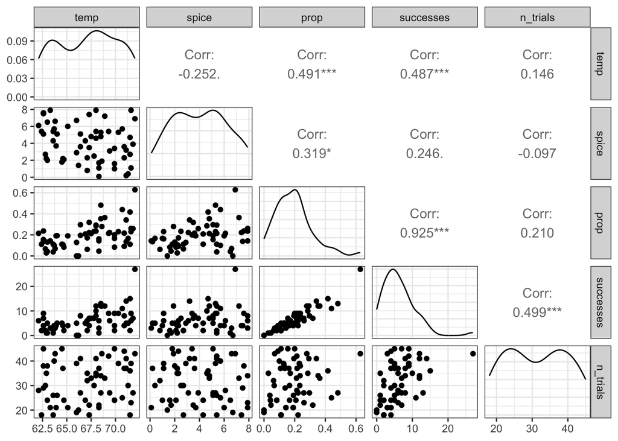

Figure 1: good graph

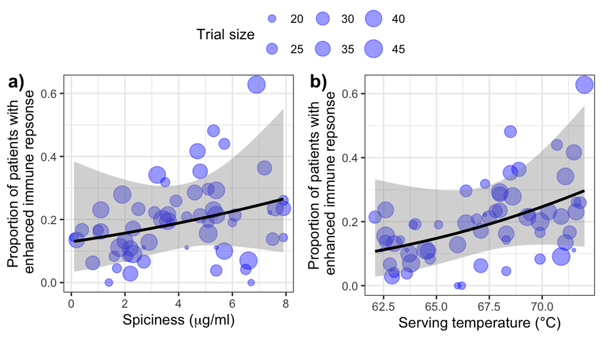

Figure 2

```r
# Draw a graph that captures the research question - shows us a better overview

ggarrange(
    ggplot(soup, aes(spice, prop)) +
      geom_point(aes(size= n_trials), alpha= .4, col= "blue") +
      geom_smooth(method= glm, method.args= list(family= "binomial"),
                  col= "black") +
      labs(x= expression("Spiciness (" * mu * "g/ml)"), #dollar notation for mu applies only for markdown not for R code
           y= "Proportion of patients with\n enhanced immune repsonse",
           size= "Trial size"),
    ggplot(soup, aes(temp, prop)) +
      geom_point(aes(size= n_trials), alpha= .4, col= "blue") +
      geom_smooth(method= glm, method.args= list(family= "binomial"),
                  col= "black") +
      labs(x= "Serving temperature (°C)",
           y= "Proportion of patients with\n enhanced immune repsonse",
           size= "Trial size"),
    nrow= 1, ncol= 2, common.legend= T, labels= c("a)", "b)"))
```

## 3 Fit model

### 3.1 Formulate and compare

Now it’s time to fit and compare some models (Table 2). As the output is in counts we will make glm models. With these data, it is quite difficult to decide which model to prefer, however, since the hypothesis involved an interaction term, lets continue with that model, `model.04`.

```r
model.00 <- glm(prop ~ 1, weights= n_trials, family = binomial, data = soup) # weights = n_trials = number of Bernoulli trials behind each proportion!
model.01 <- glm(prop ~ spice, weights= n_trials, family = binomial, data = soup)

model.02 <- glm(prop ~ temp, weights= n_trials, family = binomial, data = soup)

model.03 <- glm(prop ~ spice + temp, weights= n_trials, family = binomial, data = soup)

model.04 <- glm(prop ~ spice * temp, weights= n_trials, family = binomial, data = soup)

#compare models
kable(compare_performance(model.00, model.01, model.02, model.03, model.04), digits= 3) # Use AICc to decide: small sample!!! small AIC/ AICc indicate best model
```

Table 2: model comparison

| Name | Model | AIC | AIC_wt | AICc | AICc_wt | BIC | BIC_wt | RMSE | Sigma | Log_loss | PCP |
| --- | --- | --- | --- | --- | --- | --- | --- | --- | --- | --- | --- |
| model.00 | glm | 363.968 | 0.000 | 364.037 | 0.000 | 366.062 | 0.000 | 0.119 | 1 | 0.099 | 0.027 |
| model.01 | glm | 345.708 | 0.000 | 345.918 | 0.000 | 349.896 | 0.000 | 0.114 | 1 | 0.093 | 0.027 |
| model.02 | glm | 319.188 | 0.000 | 319.399 | 0.000 | 323.377 | 0.000 | 0.104 | 1 | 0.087 | 0.028 |
| model.03 | glm | 283.703 | 0.421 | 284.131 | 0.458 | 289.986 | 0.675 | 0.088 | 1 | 0.073 | 0.028 |
| model.04 | glm | 283.069 | 0.579 | 283.796 | 0.542 | 291.446 | 0.325 | 0.086 | 1 | 0.070 | 0.028 |

### 3.2 Validate the preferred model

Great, we’ve decided on “the best” model given the data at hand, but it might still be a bad fit to our data. Let’s make sure we can trust our selected model first, before we try to interpret it.

```r
#validate model
check_overdispersion(model.04)
```

```
# Overdispersion test

 dispersion ratio = 1.269
          p-value = 0.088
```

```
Call:
glm(formula = prop ~ spice * temp, family = binomial, data = soup,
    weights = n_trials)

Coefficients:
             Estimate Std. Error z value Pr(>|z|)
(Intercept) -7.808793   3.322023  -2.351   0.0187 *
spice       -0.860038   0.636947  -1.350   0.1769
temp         0.085338   0.048457   1.761   0.0782 .
spice:temp   0.015098   0.009329   1.618   0.1056
---
Signif. codes:  0 '***' 0.001 '**' 0.01 '*' 0.05 '.' 0.1 ' ' 1

(Dispersion parameter for binomial family taken to be 1)

    Null deviance: 172.04  on 59  degrees of freedom
Residual deviance:  85.14  on 56  degrees of freedom
AIC: 283.07

Number of Fisher Scoring iterations: 4
```

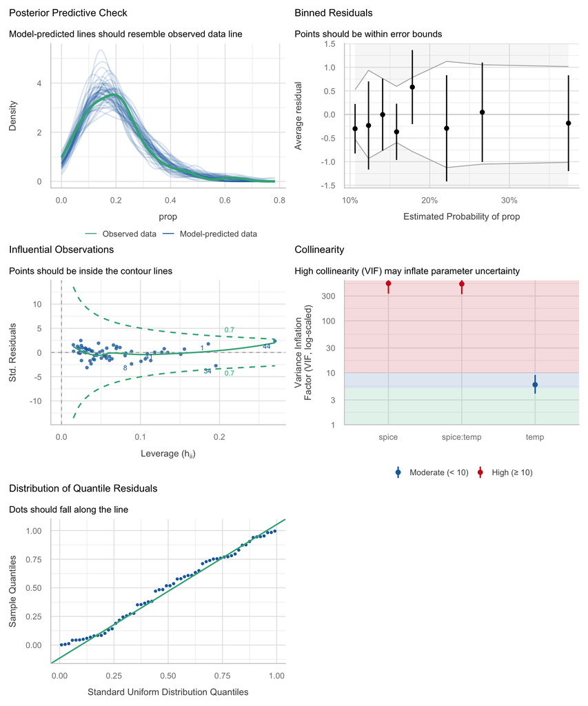

Figure 3: Model diagnostics: these look pretty good

## 4 Interpret model

```
   Min. 1st Qu.  Median    Mean 3rd Qu.    Max.
  0.100   2.200   4.100   4.060   5.475   7.900
```

```r
#refering to object in table caption is a pain look above - so if something in data changes, it will updated by itself - important for GRP: reproducibiltiy and transparancy !!
# Create table
kable(coef.table)
```

|  | Estimate | Std. Error | z value | Pr(>\|z\|) |
| --- | --- | --- | --- | --- |
| (Intercept) | -7.809 | 3.322 | -2.351 | 0.019 |
| spice | -0.860 | 0.637 | -1.350 | 0.177 |
| temp | 0.085 | 0.048 | 1.761 | 0.078 |
| spice:temp | 0.015 | 0.009 | 1.618 | 0.106 |

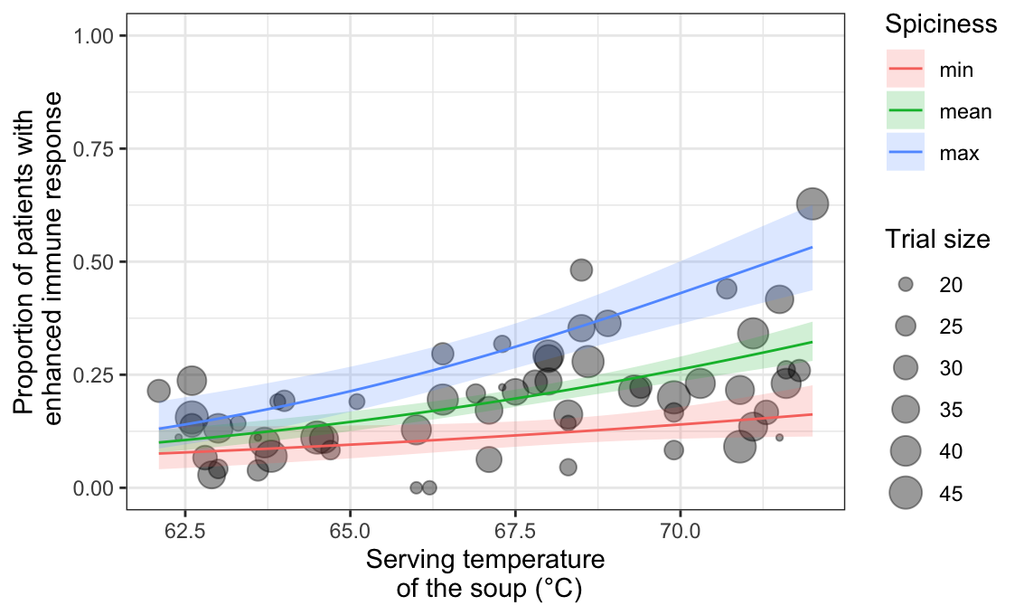

Figure 4: Raw data and model predictions to visualize the relationship between the propotion of patients that exhibited an elevated immune response, and the temperature and spicyness of the soup.

```r
# Plot predictions
  pred.plot
```